# EC4305: sawdr Missingness and Coding Audit

EC4305 Group E2 G7

2026-11-01

```r
## load libraries
library(haven)
library(dplyr)
library(tidyr)
library(ggplot2)
library(readr)
```

# 1. Purpose

This file examines missing doctor-visit outcomes in the original 1992–2003 dataset and audits the omission of positive-visit categories from the 2000–2003 coding. It documents the correction separately from the main 1992–1996 analysis.

```r
## read data
df_raw <- read_sas("https://raw.githubusercontent.com/lx-leong/ec4305_e2_g7/main/data/c9203.sas7bdat")
```

```r
names(df_raw) <- tolower(names(df_raw))

df_raw <- df_raw %>%
  mutate(across(everything(), as.numeric))

stopifnot(
  nrow(df_raw) == 160821L,
  !anyNA(df_raw$year),
  all(df_raw$year %in% 1992:2003)
)
github_data <- paste0(
  "https://raw.githubusercontent.com/",
  "lx-leong/ec4305_e2_g7/main/data/"
)
zip_filename <- "NHIS_raw.zip"

zip_url <- paste0(
  github_data,
  URLencode(zip_filename, reserved = TRUE)
)

zip_path <- tempfile(fileext = ".zip")

download.file(
  zip_url,
  zip_path,
  mode = "wb"
)

# Extract raw survey files into a temporary folder
extract_folder <- tempfile("nhis_raw_")
dir.create(extract_folder)

unzip(
  zip_path,
  exdir = extract_folder
)

raw_folder <- file.path(extract_folder, "NHIS_raw")

stopifnot(dir.exists(raw_folder))

output_folder <- file.path("output", "sawdr_audit")

dir.create(
  output_folder,
  recursive = TRUE,
  showWarnings = FALSE
)
```

# 2. Original doctor-visit missingness, 1992–2003

```r
survey_audit <- df_raw %>%
  group_by(year) %>%
  summarise(
    n_total = n(),
    sawdr_missing_n = sum(is.na(sawdr)),
    sawdr_missing_pct = 100 * mean(is.na(sawdr)),
    .groups = "drop"
  )

print(survey_audit, n = Inf)
```

```
## # A tibble: 12 × 4
##     year n_total sawdr_missing_n sawdr_missing_pct
##    <dbl>   <int>           <int>             <dbl>
##  1  1992   19496             243              1.25
##  2  1993    9585             105              1.10
##  3  1994   18030             278              1.54
##  4  1995   14802             298              2.01
##  5  1996    8838             205              2.32
##  6  1997   13838            6500             47.0
##  7  1998   12911            6255             48.4
##  8  1999   12736            6313             49.6
##  9  2000   13035            7734             59.3
## 10  2001   12967            7562             58.3
## 11  2002   12365            7236             58.5
## 12  2003   12218            7216             59.1
```

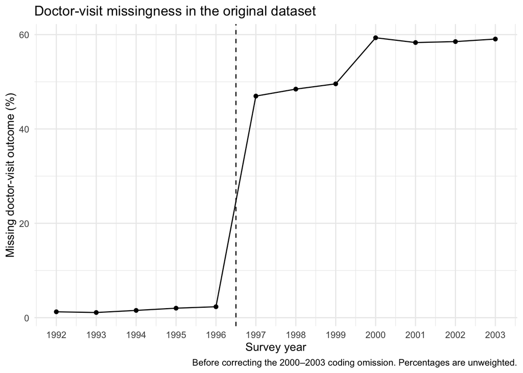

```r
p_original_missingness <- ggplot(
  survey_audit,
  aes(year, sawdr_missing_pct)
) +
  geom_point() +
  geom_line() +
  geom_vline(xintercept = 1996.5, linetype = "dashed") +
  scale_x_continuous(breaks = 1992:2003) +
  labs(
    title = "Doctor-visit missingness in the original dataset",
    x = "Survey year",
    y = "Missing doctor-visit outcome (%)",
    caption = paste(
      "Before correcting the 2000–2003 coding omission.",
      "Percentages are unweighted."
    )
  ) +
  theme_minimal()

p_original_missingness
```

# 3. Reconstructing the 2000–2003 coding

We reconstruct the original doctor-visit indicator from the raw files, then include positive-visit categories 6–8 in the corrected indicator. Unknown responses remain missing.

```r
# Starting positions of the two-character visit category
visit_positions <- c(
  "2000" = 703,
  "2001" = 763,
  "2002" = 742,
  "2003" = 725
)

find_dat <- function(survey_year, filename) {

  paths <- list.files(
    file.path(raw_folder, as.character(survey_year)),
    recursive = TRUE,
    full.names = TRUE
  )

  matched <- paths[
    tolower(basename(paths)) == tolower(filename)
  ]

  if (length(matched) != 1L) {
    stop(
      "Expected exactly one ", filename,
      " for ", survey_year,
      "; found ", length(matched)
    )
  }

  matched
}

# Read fields as text to preserve leading zeros in identifiers
read_fields <- function(path, positions) {

  starts <- vapply(positions, function(x) x[1], numeric(1))
  ends <- vapply(positions, function(x) x[2], numeric(1))
  column_order <- order(starts)

  result <- read_fwf(
    path,
    col_positions = fwf_positions(
      start = starts[column_order],
      end = ends[column_order],
      col_names = names(positions)[column_order]
    ),
    col_types = cols(.default = col_character()),
    trim_ws = TRUE,
    show_col_types = FALSE,
    progress = FALSE
  )

  if (nrow(problems(result)) > 0) {
    stop("Parsing problems in: ", path)
  }

  result
}
```

```r
audit_year <- function(survey_year) {

  visit_start <- unname(
    visit_positions[as.character(survey_year)]
  )

  person <- read_fields(
    find_dat(survey_year, "PERSONSX.DAT"),
    list(
      record_type = c(1, 2),
      year = c(3, 6),
      hhx = c(7, 12),
      fmx = c(13, 14),
      px = c(15, 16),
      intv_qrt = c(17, 17),
      sex = c(18, 18),
      age = c(19, 20),
      dob_m = c(23, 24),
      dob_y = c(25, 28)
    )
  ) %>%
    mutate(
      across(
        c(year, intv_qrt, sex, age, dob_m, dob_y),
        ~ as.numeric(.x)
      )
    )

  adult <- read_fields(
    find_dat(survey_year, "SAMADULT.DAT"),
    list(
      record_type = c(1, 2),
      year = c(3, 6),
      hhx = c(7, 12),
      fmx = c(13, 14),
      px = c(15, 16),
      ahcnoyr2 = c(visit_start, visit_start + 1)
    )
  ) %>%
    mutate(
      across(c(year, ahcnoyr2), ~ as.numeric(.x))
    )

  keys <- c("year", "hhx", "fmx", "px")
  stopifnot(
    all(person$year == survey_year),
    all(adult$year == survey_year),
    all(person$record_type == "20"),
    all(adult$record_type == "30"),
    !anyNA(person[keys]),
    !anyNA(adult[keys]),
    !anyDuplicated(person[keys]),
    !anyDuplicated(adult[keys]),
    all(
      is.na(adult$ahcnoyr2) |
        adult$ahcnoyr2 %in% c(0:8, 97:99)
    ),
    nrow(anti_join(adult, person, by = keys)) == 0
  )

  adult <- adult %>%
    select(-record_type) %>%
    mutate(sample_adult_linked = TRUE)

  person %>%
    left_join(adult, by = keys) %>%
    mutate(
      sample_adult_linked = replace_na(
        sample_adult_linked, FALSE
      ),

      birth_month = if_else(
        dob_m %in% 1:12, dob_m, NA_real_
      ),

      birth_year = if_else(
        dob_y <= year, dob_y, NA_real_
      ),

      birth_quarter = ceiling(birth_month / 3),

      age4 = (
        4 * (year - birth_year) +
          intv_qrt - birth_quarter
      ) / 4,

      female = sex - 1,

      # Reproduce the supplied construction
      sawdr_original = case_when(
        ahcnoyr2 == 0 ~ 0,
        ahcnoyr2 %in% 1:5 ~ 1,
        TRUE ~ NA_real_
      ),

      # Restore all observed positive-visit categories
      sawdr_corrected = case_when(
        ahcnoyr2 == 0 ~ 0,
        ahcnoyr2 %in% 1:8 ~ 1,
        TRUE ~ NA_real_
      ),

      sawdr_recovered = as.integer(
        ahcnoyr2 %in% 6:8
      )
    ) %>%
    filter(
      between(age, 50, 75),
      age4 > 55,
      age4 < 75
    )
}

# Audit data only
later_audit <- bind_rows(
  lapply(2000:2003, audit_year)
)
```

# 4. Validating the reconstruction

The processed dataset does not retain the original person identifiers. Therefore, we compare joint distributions of year, age, quarter-year age, sex and the original doctor-visit indicator. This is not an individual-level record match.

```r
# Check that the original construction reproduces the joint
# distribution of these variables in the supplied extract.
# This is a distribution check, not an ID-level comparison,
# because the processed extract does not retain the original IDs.
validation_vars <- c(
  "year", "age", "age4", "female", "sawdr"
)

rebuilt_counts <- later_audit %>%
  mutate(sawdr = sawdr_original) %>%
  count(
    across(all_of(validation_vars)),
    name = "n_rebuilt"
  )

reference_counts <- df_raw %>%
  filter(between(year, 2000, 2003)) %>%
  count(
    across(all_of(validation_vars)),
    name = "n_reference"
  )

validation <- full_join(
  rebuilt_counts,
  reference_counts,
  by = validation_vars
) %>%
  mutate(
    n_rebuilt = replace_na(n_rebuilt, 0L),
    n_reference = replace_na(n_reference, 0L)
  )

stopifnot(
  all(validation$n_rebuilt == validation$n_reference)
)
```

# 5. Correction results

These are unweighted counts. Remaining missing outcomes are separated into respondents without a linked Sample Adult record and respondents with a linked record but an unknown visit response.

```r
# Show the number of responses restored
correction_audit <- later_audit %>%
  group_by(year) %>%
  summarise(
    n_persons = n(),
    missing_before = sum(is.na(sawdr_original)),
    responses_recovered = sum(sawdr_recovered),
    missing_after = sum(is.na(sawdr_corrected)),
    missing_pct_before = 100 * mean(is.na(sawdr_original)),
    missing_pct_after = 100 * mean(is.na(sawdr_corrected)),
    no_sample_adult_record = sum(!sample_adult_linked),
    linked_but_missing_response = sum(
      sample_adult_linked & is.na(sawdr_corrected)
    ),
    .groups = "drop"
  )


# Verify that the missingness accounting adds up
stopifnot(
  all(
    correction_audit$missing_before -
      correction_audit$responses_recovered ==
      correction_audit$missing_after
  ),
  all(
    correction_audit$no_sample_adult_record +
      correction_audit$linked_but_missing_response ==
      correction_audit$missing_after
  )
)

print(correction_audit, n = Inf, width = Inf)
```

```
## # A tibble: 4 × 9
##    year n_persons missing_before responses_recovered missing_after
##   <dbl>     <int>          <int>               <int>         <int>
## 1  2000     13035           7734                1278          6456
## 2  2001     12967           7562                1333          6229
## 3  2002     12365           7236                1253          5983
## 4  2003     12218           7216                1308          5908
##   missing_pct_before missing_pct_after no_sample_adult_record
##                <dbl>             <dbl>                  <int>
## 1               59.3              49.5                   6372
## 2               58.3              48.0                   6140
## 3               58.5              48.4                   5875
## 4               59.1              48.4                   5815
##   linked_but_missing_response
##                         <int>
## 1                          84
## 2                          89
## 3                         108
## 4                          93
```

```r
knitr::kable(
  correction_audit %>%
    select(
      year, n_persons, missing_before,
      responses_recovered, missing_after
    ),
  caption = "Doctor-visit coding correction, 2000–2003"
)
```

Doctor-visit coding correction, 2000–2003

| year | n_persons | missing_before | responses_recovered | missing_after |
| --- | --- | --- | --- | --- |
| 2000 | 13035 | 7734 | 1278 | 6456 |
| 2001 | 12967 | 7562 | 1333 | 6229 |
| 2002 | 12365 | 7236 | 1253 | 5983 |
| 2003 | 12218 | 7216 | 1308 | 5908 |

```r
cat(
  "Total positive-visit responses restored:",
  sum(correction_audit$responses_recovered),
  "\n"
)
```

```
## Total positive-visit responses restored: 5172
```

# 6. Implications for the main analysis

Including categories 6–8 restores positive doctor-visit responses that were missing under the original coding. It does not recover responses for respondents without linked Sample Adult data or with unknown visit responses.

The correction does not resolve the changes in survey collection or the later-period weighting question. Our main analysis therefore uses 1992–1996, while this file documents the later-period coding issue separately. The audit does not modify the main cleaned dataset.

# 7. Save audit outputs

```r
write.csv(
  survey_audit,
  file.path(output_folder, "original_missingness.csv"),
  row.names = FALSE
)

write.csv(
  correction_audit,
  file.path(output_folder, "correction_audit.csv"),
  row.names = FALSE
)

write.csv(
  validation,
  file.path(output_folder, "distribution_validation.csv"),
  row.names = FALSE
)

ggsave(
  filename = file.path(
    output_folder,
    "original_sawdr_missingness.png"
  ),
  plot = p_original_missingness,
  width = 10,
  height = 6,
  dpi = 300
)

capture.output(
  sessionInfo(),
  file = file.path(output_folder, "R_session_info.txt")
)

# Remove temporary downloads and extracted files
unlink(extract_folder, recursive = TRUE)
unlink(zip_path)

normalizePath(output_folder)
```

```
## [1] "/Users/wangyunching/Desktop/NUS/Y4S1/EC4305/project/ec4305_e2_g7/data/output/sawdr_audit"
```